# Evaluation_100x25

Kento Okuyama

2023-11-30

## (very) Brief introduction

In this document, we evaluate the implementation of our frequentist implementation of the non-linear regime-switching state-space (RSSS) model estimation based on simulated data. Our implementation is a special case in which the regime-switch occurs only in one direction (i.e., there’s no switch back). Our parameter optimization consists of 300 iteration steps based on Adam and 30 initializations of the starting parameter values.

In our implementation, our objective function **sumLik** is maximized based on the gradient vector and Adam. For evaluation purpose, we also have the score function **delta**. This is simply calculated as the summed squared error of the one-step-ahead (of the last observed time points) prediction of our intra-individual latent variables. Further, we also have **sensitivity** and **specificity** based on the one-step-ahead regime prediction results.

### N=100, T=25

```
## <environment: R_GlobalEnv>
```

```
## <environment: R_GlobalEnv>
```

Before starting the evaluation of our estimated results, let’s take a look at the simulated data. We are particularly interested in the regime-switch occurence. We will summarize the percentage of subjects who made a regime switch in each of simulated realizations.

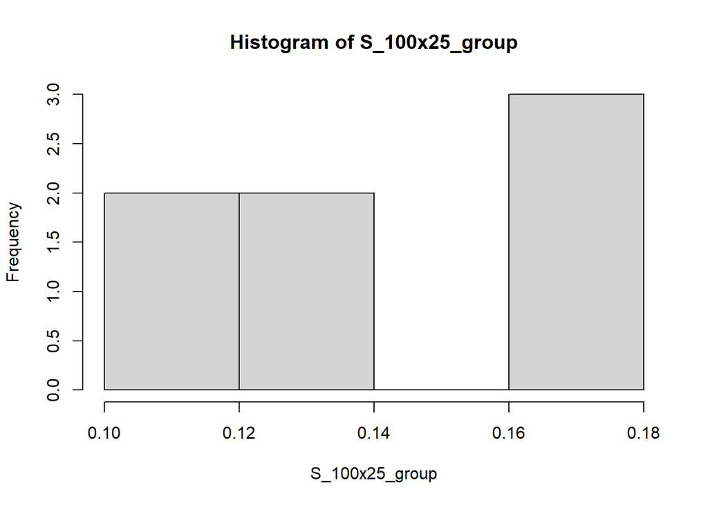

```
##    Min. 1st Qu.  Median    Mean 3rd Qu.    Max.
##  0.1100  0.1250  0.1300  0.1429  0.1700  0.1700
```

First, we check the distribution of the resulting **sumLik** in log scale.

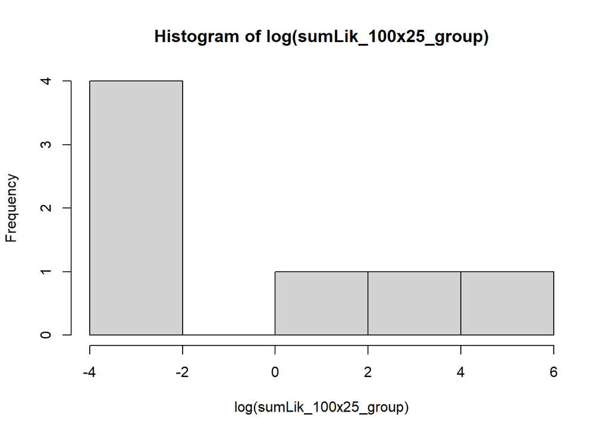

```
##    Min. 1st Qu.  Median    Mean 3rd Qu.    Max.
## -3.3076 -2.6718 -2.2275 -0.3433  1.7301  5.0151
```

It seems like there are a few instances which has much higher **sumLik** than others.

Second, we check the distribution of the resulting **delta** in log scale.

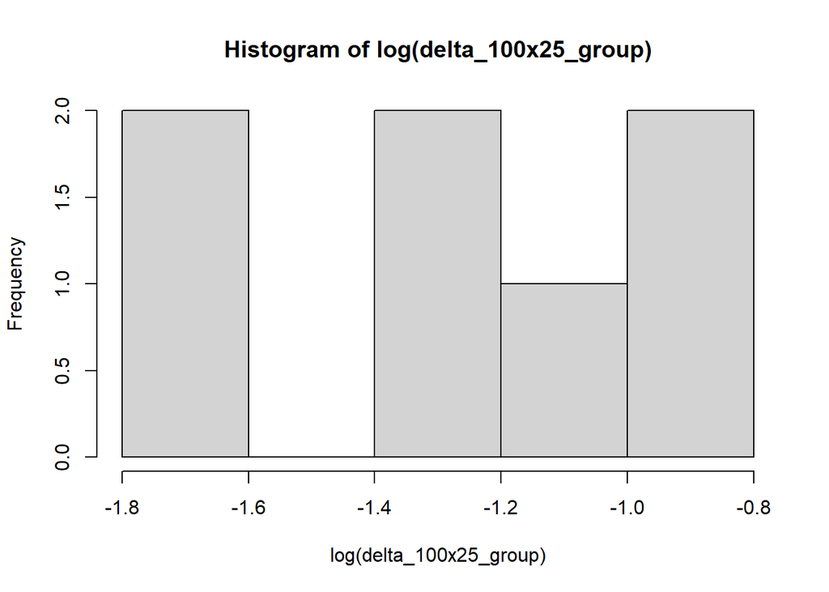

```
##    Min. 1st Qu.  Median    Mean 3rd Qu.    Max.
## -1.7151 -1.5179 -1.3046 -1.2820 -1.0214 -0.8762
```

Please note that we prefer a smaller value as it is calculated based on the prediction error.

Next, we turn our attention to how the **sumLik** and **delta** correlate (in log scale). Intuitively, we expect the negative correlation so that higher **sumLik** (maximized likelihood) relates to smaller **delta** (smaller prediction error).

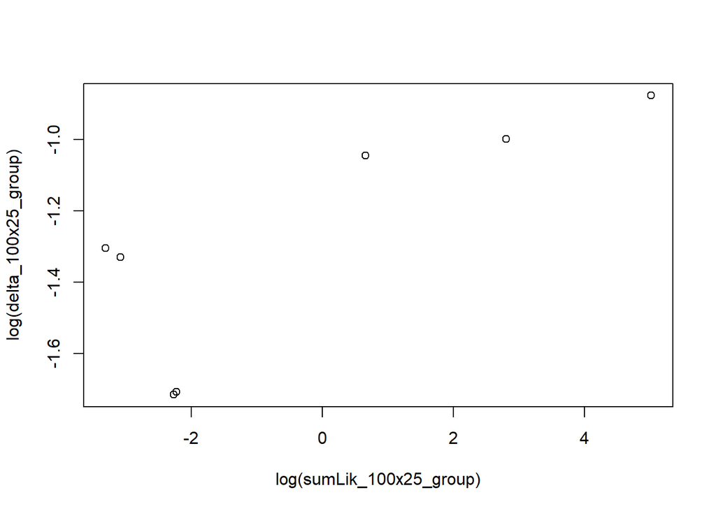

```
## [1] 0.7880097
```

Then, we check the distribution of **sensitivity** and **specificity**. First for **sensitivity**

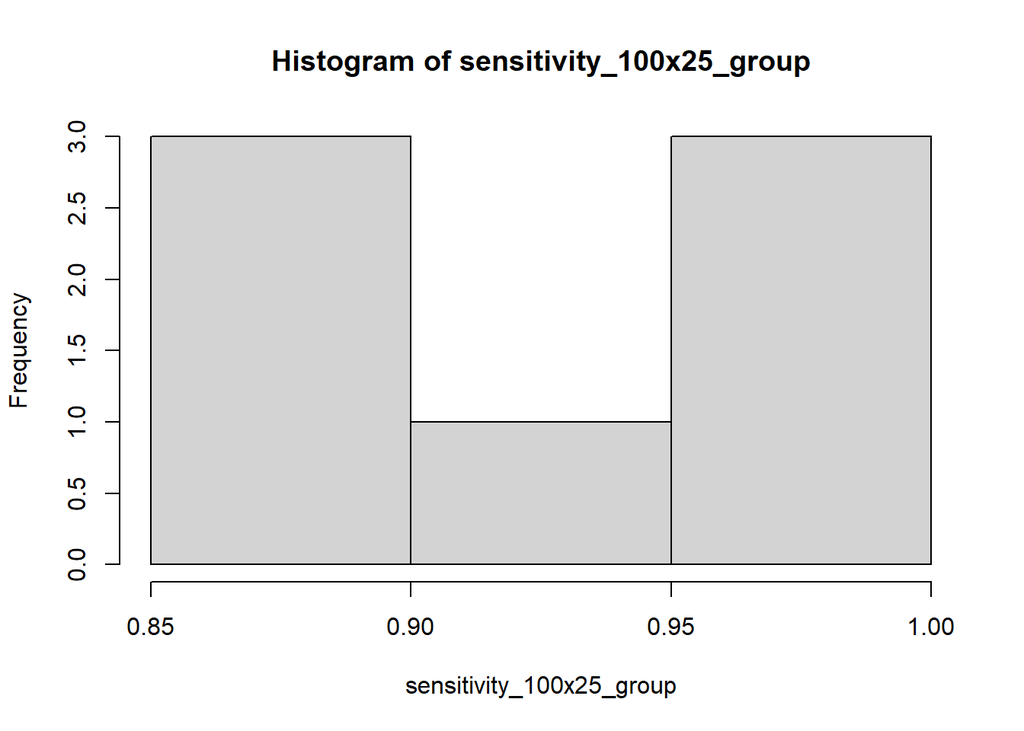

```
##    Min. 1st Qu.  Median    Mean 3rd Qu.    Max.
##  0.8824  0.8824  0.9231  0.9386  1.0000  1.0000
```

And for **specificity**

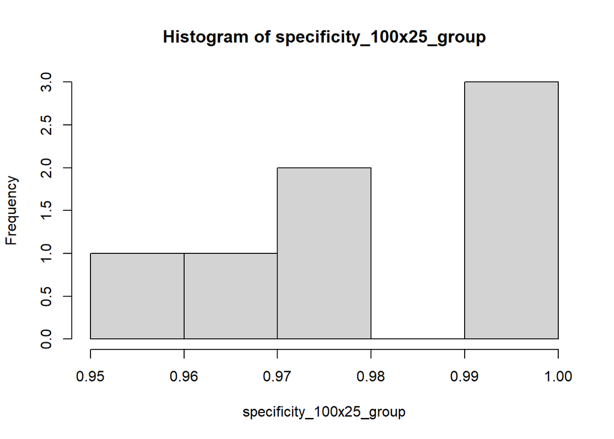

```
##    Min. 1st Qu.  Median    Mean 3rd Qu.    Max.
##  0.9551  0.9713  0.9770  0.9821  1.0000  1.0000
```

We can also check the correlation between **sensitivity** and **specificity**.

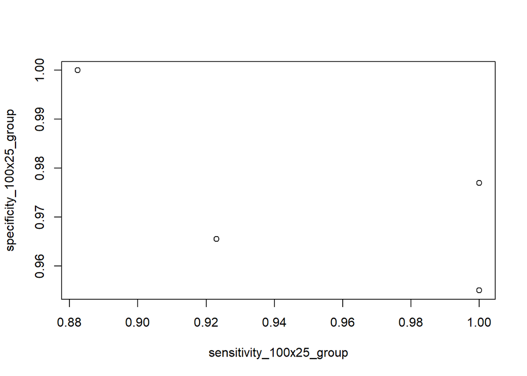

```
## [1] -0.7744669
```

Finally we examine our parameter estimation. The distribution of parameter estimation are shown below. True parameter values are in parenthesis.

```
##    B11_1 (.2)        B11_2 (.3)       B12_1 (-.1)        B12_2 (-.2)
##  Min.   :0.08067   Min.   :0.08878   Min.   :-0.26133   Min.   :-0.29318
##  1st Qu.:0.10638   1st Qu.:0.10699   1st Qu.:-0.19353   1st Qu.:-0.25720
##  Median :0.12437   Median :0.15851   Median :-0.12042   Median :-0.10984
##  Mean   :0.14493   Mean   :0.20776   Mean   :-0.13112   Mean   :-0.14158
##  3rd Qu.:0.16636   3rd Qu.:0.23508   3rd Qu.:-0.08704   3rd Qu.:-0.04310
##  Max.   :0.26399   Max.   :0.52291   Max.   : 0.02507   Max.   : 0.01257
##   B21d_1 (.8)      B21d_2 (.8)      B22d_1 (.4)         B22d_2 (.4)
##  Min.   :0.6777   Min.   :0.6393   Min.   :-0.003792   Min.   :-0.0004114
##  1st Qu.:0.7713   1st Qu.:0.8206   1st Qu.: 0.008891   1st Qu.: 0.0581147
##  Median :0.8056   Median :0.8782   Median : 0.275369   Median : 0.2403904
##  Mean   :0.7992   Mean   :0.8476   Mean   : 0.190980   Mean   : 0.2049894
##  3rd Qu.:0.8503   3rd Qu.:0.9239   3rd Qu.: 0.347174   3rd Qu.: 0.3328636
##  Max.   :0.8679   Max.   :0.9270   Max.   : 0.353151   Max.   : 0.4129900
##    B31_1 (.1)         B31_2 (.1)        B32_1 (-.1)        B31_2 (-.1)
##  Min.   :-0.11813   Min.   :-0.38338   Min.   :-0.16629   Min.   :-0.24093
##  1st Qu.:-0.04068   1st Qu.:-0.05250   1st Qu.:-0.11044   1st Qu.:-0.11605
##  Median : 0.02068   Median :-0.02029   Median :-0.08051   Median :-0.05702
##  Mean   : 0.03866   Mean   :-0.04780   Mean   :-0.07235   Mean   :-0.08203
##  3rd Qu.: 0.12117   3rd Qu.: 0.04113   3rd Qu.:-0.05325   3rd Qu.:-0.03102
##  Max.   : 0.20711   Max.   : 0.09181   Max.   : 0.06773   Max.   : 0.01785
##    Lmdd_1 (1)   Lmdd_2 (0)  Lmdd_3 (.4)       Lmdd_4 (0)  Lmdd_5 (.8)
##  Min.   :1    Min.   :0    Min.   :0.5706   Min.   :0    Min.   :0.7309
##  1st Qu.:1    1st Qu.:0    1st Qu.:0.6356   1st Qu.:0    1st Qu.:0.8272
##  Median :1    Median :0    Median :0.8856   Median :0    Median :0.8656
##  Mean   :1    Mean   :0    Mean   :0.8599   Mean   :0    Mean   :0.9263
##  3rd Qu.:1    3rd Qu.:0    3rd Qu.:0.9822   3rd Qu.:0    3rd Qu.:1.0302
##  Max.   :1    Max.   :0    Max.   :1.3276   Max.   :0    Max.   :1.1728
##    Lmdd_6 (0)   Lmdd_7 (0)   Lmdd_8 (1)   Lmdd_9 (0)  Lmdd_10 (.5)
##  Min.   :0    Min.   :0    Min.   :1    Min.   :0    Min.   :0.5327
##  1st Qu.:0    1st Qu.:0    1st Qu.:1    1st Qu.:0    1st Qu.:0.5550
##  Median :0    Median :0    Median :1    Median :0    Median :0.6216
##  Mean   :0    Mean   :0    Mean   :1    Mean   :0    Mean   :0.7608
##  3rd Qu.:0    3rd Qu.:0    3rd Qu.:1    3rd Qu.:0    3rd Qu.:0.9035
##  Max.   :0    Max.   :0    Max.   :1    Max.   :0    Max.   :1.2540
##   Lmdd_11 (0) Lmdd_12 (1.2)      Qd_1 (.2)        Qd_2 (.2)
##  Min.   :0    Min.   :0.9710   Min.   :0.0010   Min.   :0.001000
##  1st Qu.:0    1st Qu.:0.9831   1st Qu.:0.0036   1st Qu.:0.005286
##  Median :0    Median :1.0345   Median :0.1728   Median :0.172308
##  Mean   :0    Mean   :1.1203   Mean   :0.1007   Mean   :0.101013
```

[output cut: 8 more lines]

```
##  Max.   :0.37734   Max.   :0.37596   Max.   :0.37575   Max.   :0.37671
##    Rd_5 (.3)         Rd_6 (.3)        gamma1 (3.5)    gamma2_1 (1)
##  Min.   :0.02996   Min.   :0.06063   Min.   :4.117   Min.   :0.1195
##  1st Qu.:0.07392   1st Qu.:0.12259   1st Qu.:4.121   1st Qu.:0.3636
##  Median :0.37362   Median :0.37281   Median :4.122   Median :0.8147
##  Mean   :0.23953   Mean   :0.25762   Mean   :4.275   Mean   :0.7605
##  3rd Qu.:0.37443   3rd Qu.:0.37469   3rd Qu.:4.415   3rd Qu.:1.0827
##  Max.   :0.37644   Max.   :0.37535   Max.   :4.616   Max.   :1.4970
##   gamma2_2 (1)
##  Min.   :0.2963
##  1st Qu.:0.4588
##  Median :0.6721
##  Mean   :0.8223
##  3rd Qu.:1.1745
##  Max.   :1.5214
```

Finally, we check the rate of regime-switch prediction by the time of the final prediction which we call the dropout prediction rate.

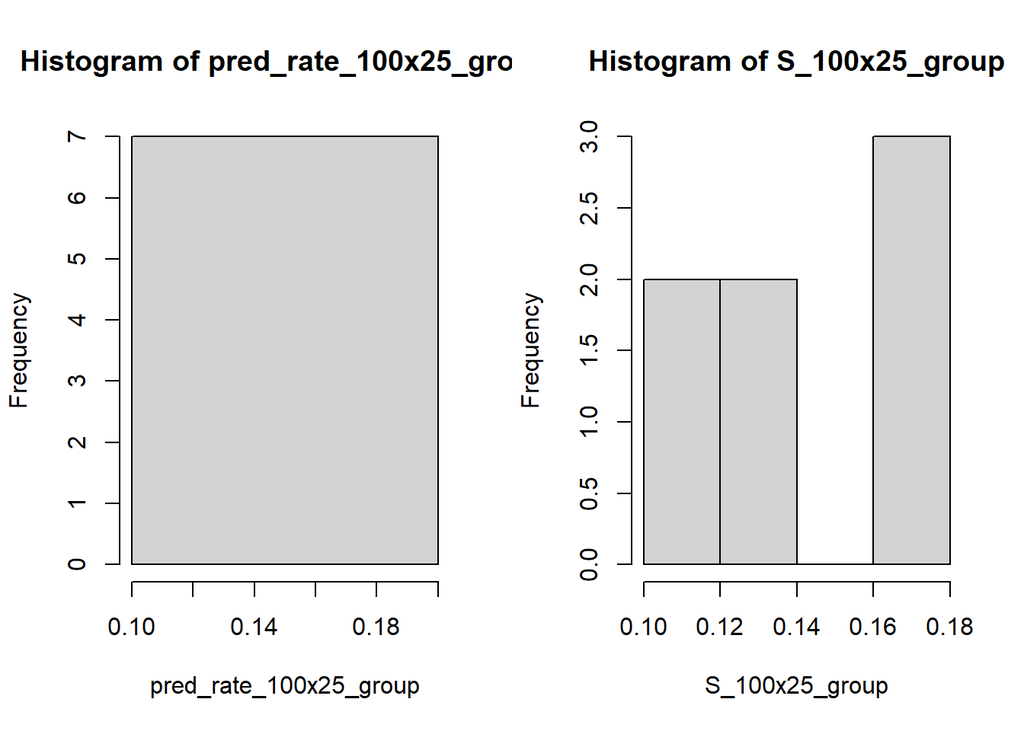

```
##    Min. 1st Qu.  Median    Mean 3rd Qu.    Max.
##    0.15    0.15    0.15    0.15    0.15    0.15
```

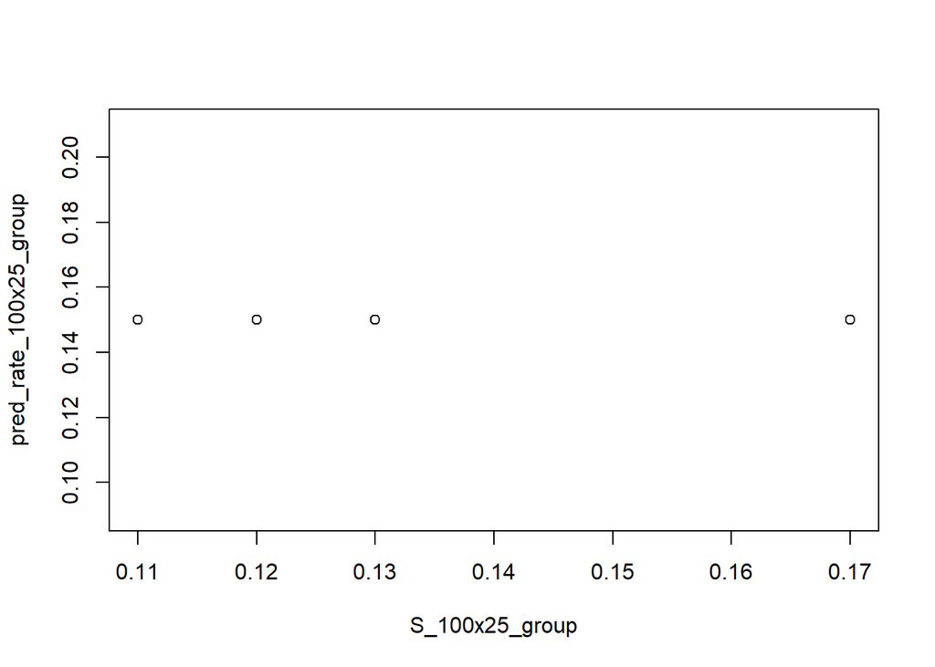

```
## [1] NA
```